# Fatal Encounters With Police

Anthony Vega

10/13/2021

## R Markdown

Throughout the past few decades we have seen several instances of police killing unarmed men and women through video captured by bystanders. There are several instances where the shootings/killings are justified, however there are many that are questionable at best. The image of George Floyd begging for his life has been ingrained on many American minds. With the conviction of former police officer Derick Chauvin, many rejoiced that an officer was actually being held accountable.

In this visualization, I will be taking a look at a dataset consisting of fatal encounters with police officers. I will examine possible connections between variables such as race, region, mental illness, and whether the suspect was armed or unarmed. To do this, I will utilize visualizations including bar plots, map plots, and scatter plots.

```r
fatal_encounters <- read_csv("data/fatal_encounters.csv") %>%
  clean_names()
```

```
## * `` -> ...33
## * `` -> ...34
```

```r
# Select only the columns needed
fatal_tidy <- fatal_encounters %>%
  select("state", "location_of_death_county", "date_of_injury_resulting_in_death_month_day_year", "age", "gender", "race", "highest_level_of_force", "intended_use_of_force_developing", "foreknowledge_of_mental_illness_internal_use_not_for_analysis", "armed_unarmed", "aggressive_physical_movement")

# Remove future entry. This entry. This entry seems to be a dummy entry
fatal_tidy = fatal_tidy[-30861,]



names(fatal_tidy)[names(fatal_tidy) == "date_of_injury_resulting_in_death_month_day_year"] <- "date"
names(fatal_tidy)[names(fatal_tidy) == "foreknowledge_of_mental_illness_internal_use_not_for_analysis"] <- "mental_illness"

fatal_tidy <- fatal_tidy %>%
  mutate(date = parse_date(date, "%m%.%d%.%Y"))


# Get rid of any observations where race is unspecified
fatal_tidy_race <- fatal_tidy %>%
  filter(race != "Race unspecified")


# Get rid of any observations where armed_unarmed is N/A, None or Duplicate of 13419?
fatal_tidy_race_armed_unarmed <- fatal_tidy_race %>%
  filter(armed_unarmed != "N/A" & armed_unarmed != "None" & armed_unarmed != "Duplicate of 13419?")



# Get a count for the number of fatal encounters in each state
fatal_encounters_by_state <- fatal_tidy_race_armed_unarmed %>%
  count(state)

# Combine with statepop
fatal_encounters_by_state <- statepop %>%
  left_join(fatal_encounters_by_state, by = c("abbr" = "state"))


# Create subsets for state data for maps of California and Texas
cali_fatal_encounters_by_county <- fatal_tidy_race_armed_unarmed %>%
  filter(state == "CA") %>%
  count(location_of_death_county)

cali_fatal_encounters <- fatal_tidy_race_armed_unarmed %>%
  filter(state == "CA")

cali_counties <- countypov %>%
  filter(abbr == "CA")

# Remove " County" from countypov data to match county names in fatal encounters data in order to join
cali_counties <- cali_counties %>%
  mutate(county = sub(" County", "", county))

cali_fatal_encounters_by_county <- cali_counties %>%
  left_join(cali_fatal_encounters_by_county, by = c("county" = "location_of_death_county"))

 # where age is NA
texas_fatal_encounters <- fatal_tidy_race_armed_unarmed %>%
  filter(state == "TX")

texas_fatal_encounters_by_county <- fatal_tidy_race_armed_unarmed %>%
  filter(state == "TX") %>%
  count(location_of_death_county)

texas_counties <- countypov %>%
  filter(abbr == "TX")

# Remove " County" from county column in order to match with the values in order to match texas_fatal_encounters_by_county
texas_counties <- texas_counties %>%
  mutate(county = sub(" County", "", county))

texas_fatal_encounters_by_county <- texas_counties %>%
  left_join(texas_fatal_encounters_by_county, by = c("county" = "location_of_death_county"))

fatal_encounters_by_year <- fatal_tidy %>%
  count(date)

# Count of fatal encounters by mental illness
fatal_encounters_by_mental_illness <- fatal_tidy %>%
  count(mental_illness)

fatal_encounters_agressive_phys_movement <- fatal_tidy %>%
  filter(aggressive_physical_movement != "NA" & armed_unarmed != "Duplicate of 13419?" &
           armed_unarmed != "Duplicate of 13457?")


unarmed_no_aggressive_movement <- fatal_encounters_agressive_phys_movement %>%
  filter(armed_unarmed == "Unarmed" &
           aggressive_physical_movement == "None")
```

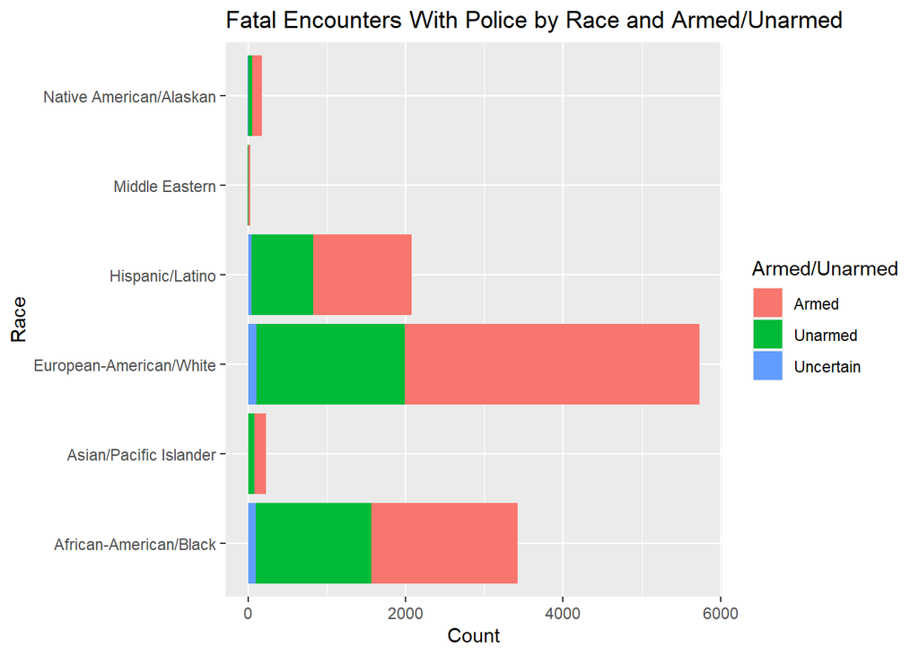

```r
# bar plot for fatal encounters by race with armed_unarmed as the fill
fatal_tidy_race_armed_unarmed %>%
  group_by(race, armed_unarmed) %>%
  ggplot(aes(y = race, fill = armed_unarmed)) +
  labs(title = "Fatal Encounters With Police by Race and Armed/Unarmed", x = "Count", y = "Race") +
  scale_fill_discrete(name = "Armed/Unarmed") +
  geom_bar()
```

A standard bar chart is used to visualize fatal encounters with police based on race and whether the victim was armed or unarmed. There are three categories that stand out: Hispanic/Latino, European-American/White, and African American. In each category, the majority of victims were armed. However, when looking at the data for African-American/Black, the difference between armed and unarmed is smaller. There are 1864 observations where the victim was armed against 1466 that were unarmed. For European-American/White, there are 3746 victims who were armed and 1887 that were unarmed. Finally, looking at the data for Hispanic/Latino, there are 1252 victims who were armed and 782 that were unarmed.

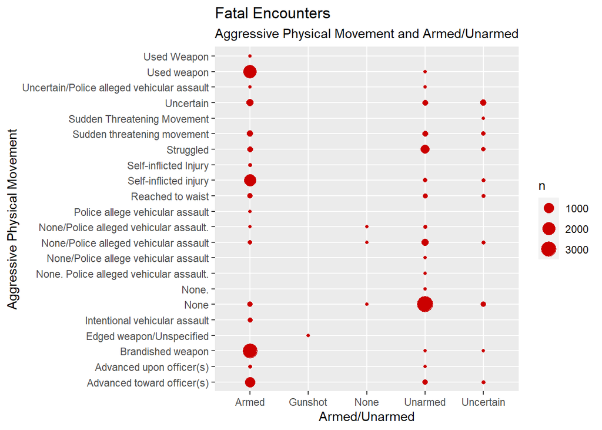

```r
fatal_encounters_agressive_phys_movement %>%
  ggplot(aes(y = aggressive_physical_movement, x = armed_unarmed)) +
  labs(title = "Fatal Encounters", subtitle = "Aggressive Physical Movement and Armed/Unarmed", x = "Armed/Unarmed", y = "Aggressive Physical Movement") +
  geom_count(color = "#CB0000")
```

When plotting fatal encounters by aggressive physical movement and armed/unarmed we see a large amount of those who were armed that used a weapon, brandished weapon, and advanced toward officers. In addition there are a large number of people under armed with self-inflicted injury. Looking at the people who were unarmed we see a large amount of those with no aggressive physical movement at all. This is obviously a problem to have so many unarmed people who did not make any aggressive physical movement have fatal encounters with police. The next highest of unarmed people were listed as struggling with police. Again, this is a problem. While struggling is essentially resisting arrest, which is a crime, it is not something that, by itself, warrants police to fatally injure a suspect.

There are some observations that don’t seem to make sense. For example, there are a number observations in the unarmed category that are listed as using a weapon or that brandished a weapon. This could be errors in the data or a misunderstanding as to what one may consider a weapon.

```r
armed_unarmed_black_count <- fatal_tidy_race_armed_unarmed %>%
  filter(race == "African-American/Black")  %>%
  count(armed_unarmed)

armed_unarmed_white_count <- fatal_tidy_race_armed_unarmed %>%
  filter(race == "European-American/White")  %>%
  count(armed_unarmed)


armed_unarmed_hisp_count <- fatal_tidy_race_armed_unarmed %>%
  filter(race == "Hispanic/Latino") %>%
  count(armed_unarmed)
```

```r
unarmed_no_aggressive_movement <- unarmed_no_aggressive_movement %>%
  count(race)

fatal_encounters_count_by_race <- fatal_tidy_race_armed_unarmed %>%
  count(race)

unarmed_no_aggressive_movement
```

```
## # A tibble: 7 x 2
##   race                        n
##   <chr>                   <int>
## 1 African-American/Black    985
## 2 Asian/Pacific Islander     56
## 3 European-American/White  1304
## 4 Hispanic/Latino           524
## 5 Middle Eastern              2
## 6 Native American/Alaskan    34
## 7 Race unspecified          585
```

```r
fatal_encounters_count_by_race
```

```
## # A tibble: 6 x 2
##   race                        n
##   <chr>                   <int>
## 1 African-American/Black   3428
## 2 Asian/Pacific Islander    231
## 3 European-American/White  5737
## 4 Hispanic/Latino          2078
## 5 Middle Eastern             28
## 6 Native American/Alaskan   178
```

When I took a look at the amount of unarmed people who did not make any aggressive physical movement, I noticed that the percentage of African-American/Black people is higher than that of European-American/White. Overall the data contains 5,737 European-American/White with 1,304 of them unarmed with no aggressive physical movement, or ~22%. There are 3,428 African-American/Black people who had fatal encounters with 985 of them unarmed and did not make any aggressive physical movement, or ~29%.

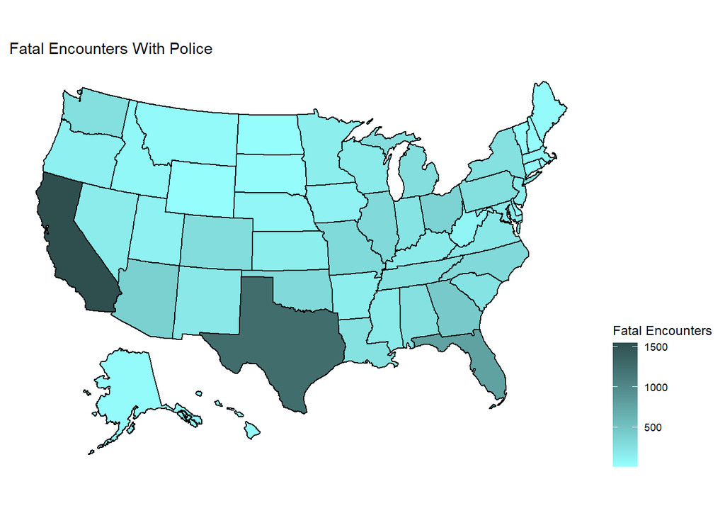

```r
# Map of US displaying fatal encounters
fatal_encounters_by_state %>%
  plot_usmap(data = .,
             values = "n") +
  labs(title = "Fatal Encounters With Police") +
  theme(legend.position = "right") +
  scale_fill_continuous(name = "Fatal Encounters", low = "darkslategray1", high = "darkslategrey")
```

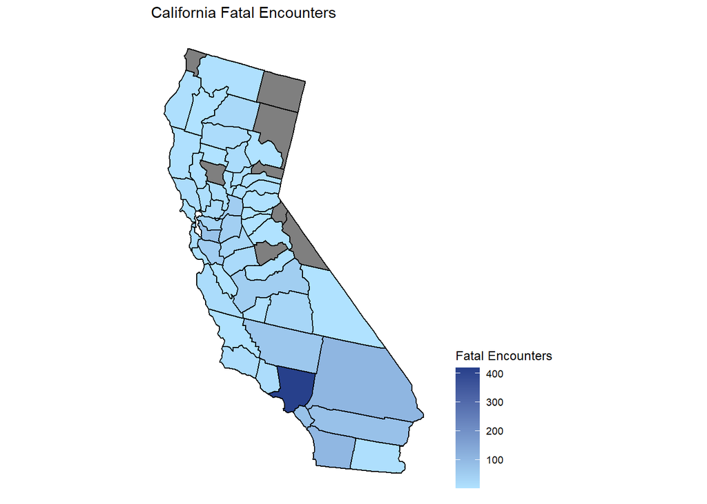

```r
# California fatal encounter map by county
plot_usmap(data = cali_fatal_encounters_by_county, values = "n", include = c("CA"), labels = FALSE) +
  labs(title = "California Fatal Encounters") +
  scale_fill_continuous(name = "Fatal Encounters", low = "lightskyblue1", high = "royalblue4") +
  theme(legend.position = "right")
```

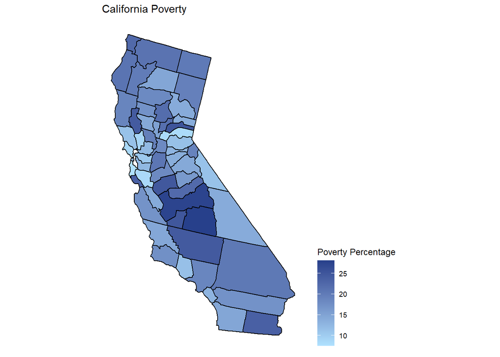

```r
# California poverty map by county
plot_usmap(data = cali_fatal_encounters_by_county, values = "pct_pov_2014", include = c("CA"), labels = FALSE) +
  labs(title = "California Poverty") +
  scale_fill_continuous(name = "Poverty Percentage", low = "lightskyblue1", high = "royalblue4") +
  theme(legend.position = "right")
```

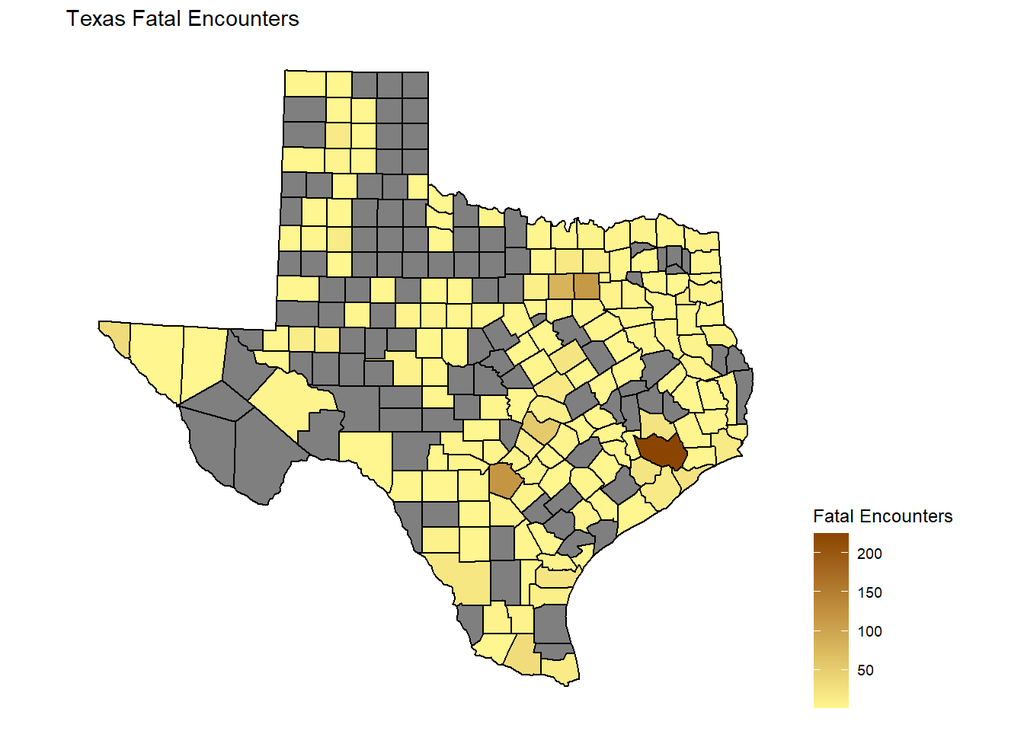

```r
# Texas map by county
plot_usmap(data = texas_fatal_encounters_by_county, values = "n", include = c("TX"), labels = FALSE) +
  labs(title = "Texas Fatal Encounters") +
  scale_fill_continuous(name = "Fatal Encounters", low = "khaki1", high = "darkorange4") +
  theme(legend.position = "right")
```

[figure not shown]

```r
# Texas map by county
plot_usmap(data = texas_fatal_encounters_by_county, values = "pct_pov_2014", include = c("TX"), labels = FALSE) +
  labs(title = "Texas Fatal Encounters") +
  scale_fill_continuous(name = "Fatal Encounters", low = "khaki1", high = "darkorange4") +
  theme(legend.position = "right")
```

A usmap plot is used to get a better look at how the data is distributed across the United States. There are two states that clearly stand out—California and Texas. Florida has a higher rate than most states and appears to have the third highest amount of fatal encounters

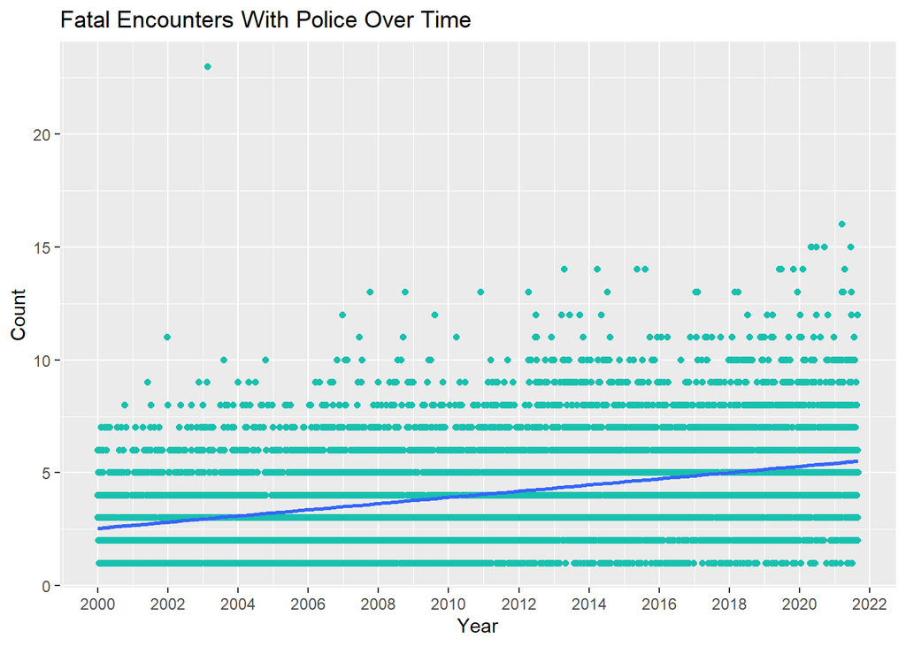

```r
# Plot of fatal encounters over time by the date
fatal_encounters_by_year %>%
  ggplot(aes(x = date, y = n)) + geom_point(color = "#18C0AE") +
  labs(title = "Fatal Encounters With Police Over Time", x = "Year", y = "Count") +
  geom_smooth(formula = y ~ x, method = "lm") +
  scale_x_date(date_breaks = "2 years", date_labels = "%Y")
```

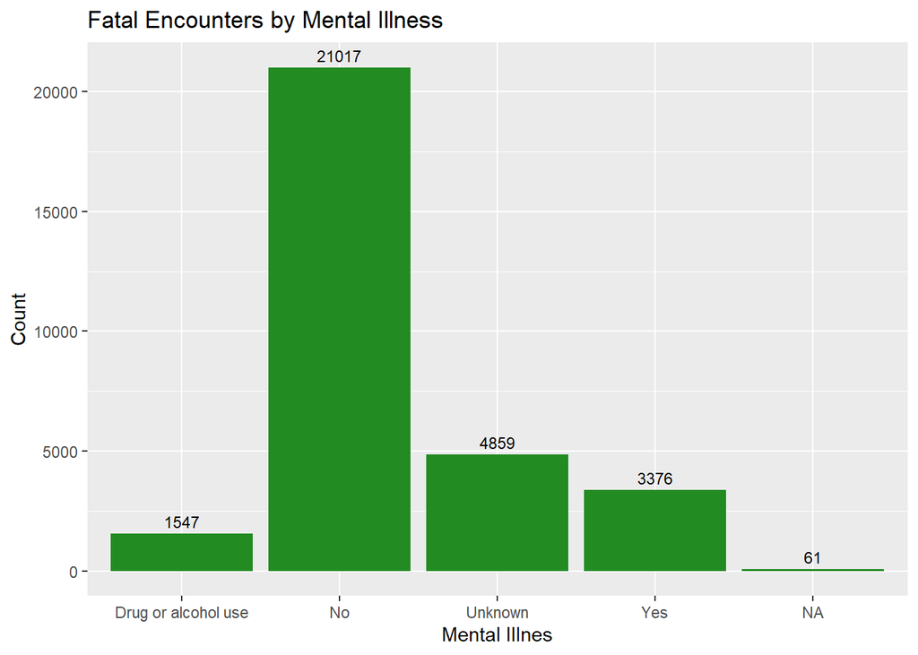

```r
fatal_encounters_by_mental_illness %>%
  ggplot(aes(x = mental_illness, y = n)) +
  labs(title = "Fatal Encounters by Mental Illness", x = "Mental Illnes", y = "Count") +
  geom_bar(stat = 'identity', fill = "forestgreen") +
  geom_text(aes(label = n), vjust = -0.5, size = 3)
```

An additional subset for the amount of fatal encounters by mental illness is created. There are five categories or answers: Drug or alcohol use (meaning the victim was under the influence at the time of the incident), no, yes, unknown, and N/A. Surprisingly, the majority of fatal encounters did not involve someone with mental illness with 21,017 fatal encounters. There is still a high number of those who did have a mental illness at 3,376 fatal encounters but it is nowhere near the amount of those who did not.